# Graph-constrained Regression with Enhanced Regulariazation Parameters Selection: intro and usage examples

Marta Karas marta.karass@gmail.com

2017-05-29

# The two-formulas intro

## `riPEER` estimator

`mdpeer` provides penalized regression method `riPEER()` to estimate a linear model:
$$y = X\beta + Zb + \varepsilon$$
where:

- $y$ - response
- $X$ - input data matrix
- $Z$ - input data matrix
- $\beta$ - regression coefficients, *not penalized* in estimation process
- $b$ - regression coefficients, *penalized* in estimation process and for whom there is, *possibly*[^1], a **prior graph of similarity / graph of connections** available

`riPEER()` estimation method uses a penalty being a linear combination of a graph-based and ridge penalty terms:

$$\widehat{\beta}, \widehat{b}= \underset{\beta,b}{arg \; min}\left \{ (y - X\beta - Zb)^T(y - X\beta - Zb) + \lambda_Qb^TQb + \lambda_Rb^Tb\right \},$$
where:

- $Q$ - a graph-originated penalty matrix; typically: a graph Laplacian matrix,
- $\lambda_Q$ - regularization parameter for a graph-based penalty term
- $\lambda_R$ - regularization parameter for ridge penalty term

## A word about the `riPEER` penalty properties

- A graph-originated penalty matrix $Q$ allows imposing similarity between coefficients of variables which are *similar* (or *connected*), based on some graph given.
- Adding ridge penalty term, $\lambda_Rb^Tb$, even with very small $\lambda_R$, eliminates computational issues arising from singularity in a graph-originated penalty matrix.
- Also, in cases when the graph information given is only partially informative / not informative about regression coefficients, ridge penalty provides partial / full regularization in the estimation.

## A cool thing about regularization parameters selection

They are **estimated automatically** as ML estimators of equivalent Linear Mixed Models optimization problem (see: Karas et al. (2017)).

# Examples

## example 1: `riPEER` used with informative graph information

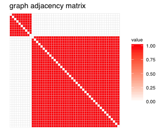

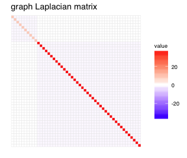

```r
library(mdpeer)

n  <- 100
p1 <- 10
p2 <- 40
p  <- p1 + p2

# Define graph adjacency matrix
A <- matrix(rep(0, p*p), nrow = p, ncol = p)
A[1:p1, 1:p1] <- 1
A[(p1+1):p, (p1+1):p] <- 1
diag(A) <- rep(0,p)

# Compute graph Laplacian matrix
L <- Adj2Lap(A)

vizu.mat(A, "graph adjacency matrix", 9); vizu.mat(L, "graph Laplacian matrix", 9)
```

```r
# simulate data objects
set.seed(1)
Z <- scale(matrix(rnorm(n*p), nrow = n, ncol = p))
X <- cbind(1, scale(matrix(rnorm(n*3), nrow = n, ncol = 3))) # cbind with 1s col. for intercept
b.true <- c(rep(1,p1), rep(0,p2)) # coefficients of interest (penalized)
beta.true <- c(0, runif(3)) # intercept=0 and 3 coefficients (non-penalized)
eta <- Z %*% b.true + X %*% beta.true
R2 <- 0.5                         # assumed variance explained
sd.eps <- sqrt(var(eta) * (1 - R2) / R2)
error <- rnorm(n, sd = sd.eps)
y <- eta + error
```

$b$ estimation

- `riPEER`: graph Laplacian matrix `L` used as a penalty matrix $Q$
- `riPEER`: graph highly informative about regression coefficients -> relatively high contribution of graph-based penalty over contribution of ridge penalty (`lambda.Q` >> `lambda.R`)

```r
# estimate with riPEER
riPEER.out   <- riPEER(Q = L, y = y, Z = Z, X = X, verbose = FALSE)
b.est.riPEER <- riPEER.out$b.est
# (graph penalty regulatization parameter, ridge penalty regularization parameter)
c(riPEER.out$lambda.Q, riPEER.out$lambda.R)
```

```
## [1] 14.92846  1.83456
```

```r
# estimate with cv.glmnet
library(glmnet)
cv.out.glmnet <- cv.glmnet(x = cbind(X,Z), y = y, alpha = 0, intercept = FALSE)
b.est.cv.glmnet <- unlist(coef(cv.out.glmnet))[5:54] # exclude intercept and covs
```

$b$ estimates plot

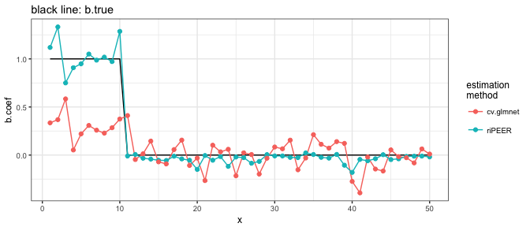

$b$ estimation error

```r
MSEr <- function(b.true, b.est) sum((b.true-b.est)^2)/sum(b.true^2)

# (riPEER error, cv.glmnet error)
c(MSEr(b.true,b.est.riPEER), MSEr(b.true,b.est.cv.glmnet))
```

```
## [1] 0.04080697 0.59165654
```

## example 2: `riPEER` used with non-informative graph information

- use same graph information as above
- simulate truen $b$ coefficients about which the graph given is not informative

```r
# simulate data objects
set.seed(1)
Z <- scale(matrix(rnorm(n*p), nrow = n, ncol = p))
X <- cbind(1, scale(matrix(rnorm(n*3), nrow = n, ncol = 3)))
b.true <- rep(c(-1,1), p/2)

# coefficients of interest (penalized)
beta.true <- c(0, runif(3)) # intercept=0 and 3 coefficients (non-penalized)
eta <- Z %*% b.true + X %*% beta.true
R2 <- 0.5                         # assumed variance explained
sd.eps <- sqrt(var(eta) * (1 - R2) / R2)
error <- rnorm(n, sd = sd.eps)
y <- eta + error
```

$b$ estimation

- `riPEER`: graph non-informative about regression coefficients -> relatively high contribution of ridge penalty over contribution of graph-based penalty (`lambda.Q` << `lambda.R`)

```r
# estimate with riPEER
riPEER.out   <- riPEER(Q = L, y = y, Z = Z, X = X, verbose = FALSE)
b.est.riPEER <- riPEER.out$b.est
c(riPEER.out$lambda.Q, riPEER.out$lambda.R)
```

```
## [1]  1.44594 14.96809
```

```r
# estimate with cv.glmnet
cv.out.glmnet <- cv.glmnet(x = cbind(X,Z), y = y, alpha = 0, intercept = FALSE)
b.est.cv.glmnet <- unlist(coef(cv.out.glmnet))[5:54] # exclude intercept and covs
```

$b$ estimates plot

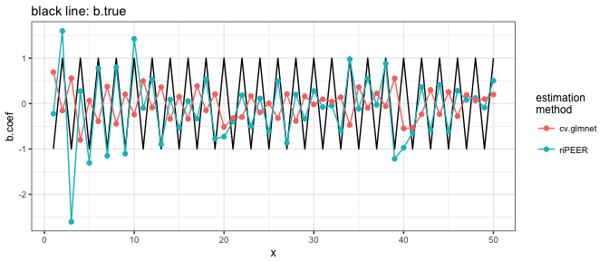

$b$ estimation error

```r
MSEr <- function(b.true, b.est) sum((b.true-b.est)^2)/sum(b.true^2)

# (riPEER error, cv.glmnet error)
c(MSEr(b.true,b.est.riPEER), MSEr(b.true,b.est.cv.glmnet))
```

```
## [1] 0.5596557 1.5799423
```

## example 3: `riPEERc` used as ordinary ridge estimator

- `riPEERc` - method for *Graph-constrained regression with addition of a small ridge term to handle the non-invertibility of a graph Laplacian matrix*
- one might provide diagonal matrix as its `Q` argument to use it as ordinary ridge estimator

```r
# example based on `glmnet::cv.glmnet` CRAN documentation
set.seed(1010)
n=1000;p=100
nzc=trunc(p/10)
x=matrix(rnorm(n*p),n,p)
beta=rnorm(nzc)
fx= x[,seq(nzc)] %*% beta
eps=rnorm(n)*5
y=drop(fx+eps)
set.seed(1011)
cvob1=cv.glmnet(x,y, alpha = 0)
est.cv.glmnet <- coef(cvob1)[-c(1)] # exclude intercept and covs

# use riPEERc (X has column of 1s to represent intercept in a model)
riPEERc.out <- riPEERc(Q = diag(p), y = matrix(y), Z = x, X = matrix(rep(1,n)))
est.riPEERc <- riPEERc.out$b.est
```

$b$ estimates plot

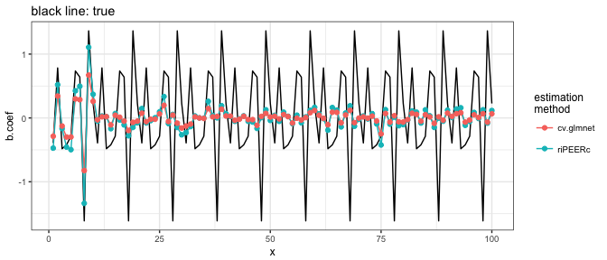

$b$ estimation error

```r
MSEr <- function(b.true, b.est) sum((b.true-b.est)^2)/sum(b.true^2)

# (riPEER error, cv.glmnet error)
c(MSEr(beta,est.riPEERc), MSEr(beta,est.cv.glmnet))
```

```
## [1] 9.398393 9.415188
```

## Conclusion

- Example 1: graph highly informative about regression coefficients: `riPEER` outperforms `cv.glmnet` in $b$ coefficients estimation significantly
- Example 2: graph non-informative about regression coefficients: `riPEER` still outperforms `cv.glmnet` in $b$ coefficients estimation
- Example 3: `riPEERc` used as ordinary ridge estimator (with regularization parameter being estimated automatically) outperforms `cv.glmnet` in coefficients estimation

# References

1. Karas, M., Brzyski, D., Dzemidzic, M., J., Kareken, D.A., Randolph, T.W., Harezlak, J. (2017). Brain connectivity-informed regularization methods for regression. doi: https://doi.org/10.1101/117945
[^1]: `riPEER` might be also used as ridge regression estimator by supplying a diagonal matrix as `Q` argument. see: Examples. Example 3.